# Researcher Variability in Replications: Replication File, Step 2

| Metric | Definition | Measure |
| --- | --- | --- |
| *Verification* (verif) | The direction of the regression coefficient is the same as the original & either within 0.05 absolute difference or the same significance at p<0.05 threshold | 1=verified, 0=not |
| *Exact Verification* (exact) | The value of the replication odd-ratio is identical to the second decimal place of the original | 1=exact, 0=not |
| *Replication Deviance* (deviance_abs) | The absolute deviation of the replication from the original | continuous measure starting from exact (=0) and increasing positive values |

```r
rm(list = ls())
library(pacman)


pacman::p_load("dplyr", "readr", "lattice", "tidyr", "readxl", "knitr", "boot", "ragg", "kableExtra", "ggpubr","lme4", "jtools","sjPlot", "sjmisc", "sjlabelled", "rvest", "lavaan", "lavaanPlot", "see")
```

```r
# load data from 01_Data_Prep
load(file = "data/data.Rdata")

#remove original study from data
cri_long <- subset(cri_long, insamp == 1)
cri_cur_long <- subset(cri_cur_long, insamp == 1)

# Team 33 missing data on stat degree, code to 0
cri_cur_long$stat_degree <- ifelse(is.na(cri_cur_long$stat_degree), 0, cri_cur_long$stat_degree)

# Make soc degree variable (versus Poli Sci and Other)
cri_cur_long$degree_soc <- ifelse(is.na(cri_cur_long$degree), 3, cri_cur_long$degree)

cri_cur_long$degree_soc <- ifelse(cri_cur_long$degree_soc == 1, 1, 0)

cri_long$degree_soc <- ifelse(is.na(cri_long$degree), 3, cri_long$degree)

cri_long$degree_soc <- ifelse(cri_long$degree_soc == 1, 1, 0)

# disable scientific notation
options(scipen = 999)
```

## Figure 1

```r
plot1 <- ggplot(cri_long, aes(x = count, y = deviance_abs, color = Exp1, shape = Exp1)) +
  geom_point(size = 2.5) +
  coord_cartesian(ylim=c(0, 0.5)) +
  ylab("Replicated Effect\n(deviance from original)") +
  scale_color_manual(values = c("#009E73","#D55E00"), name = "Replication Group", labels = c("Transparent","Opaque")) +
  scale_shape_manual(values = c(6,2)) +
  theme(axis.title.x = element_blank(),
        axis.ticks.x = element_blank(),
        axis.text.x = element_blank(),
        axis.text.y = element_text(size = 12, color = "black"),
        axis.line.x = element_line(),
        axis.line.y = element_line(),
        legend.position = "none",
        plot.background = element_blank(),
        panel.background = element_blank(),
        legend.background = element_blank(),
        legend.key = element_blank(),
        legend.text = element_text(size = 11)) +
  guides(color = guide_legend(override.aes = list(shape = c(19,19), size=5, fill = NA)), shape = F)


# get means to add
mean0 <- round(mean(cri_long$deviance_abs[cri_long$Exp1 == 0], na.rm = T),3)
mean1 <- round(mean(cri_long$deviance_abs[cri_long$Exp1 == 1], na.rm = T),3)

plot2 <- ggboxplot(cri_long, "Exp1","deviance_abs", color = "Exp1",
                   whisklty = 0, palette = c("#009E73","#D55E00"),
                   outlier.shape = NA, size = 1) +
  coord_cartesian(ylim=c(0, 0.04)) +
  xlab("Group") +
  scale_fill_discrete(name = "Replication Group", labels = c("Transparent","Opaque")) +
  annotate(geom="text", x=1.1, y=0.0145, label = paste0("mean"),
              color="#009E73", size = 3, hjust = 0) +
  annotate(geom="text", x=2.1, y=0.036, label = paste0("mean"),
              color="#D55E00", size = 3, hjust = 0) +
  annotate(geom="text", x=1.1, y=0.013, label = paste0("deviance"),
              color="#009E73", size = 3, hjust = 0) +
  annotate(geom="text", x=2.1, y=0.0345, label = paste0("deviance"),
              color="#D55E00", size = 3, hjust = 0) +
  annotate(geom="text", x=1.1, y=0.011, label = paste0(mean1),
              color="#009E73", size = 3, hjust = 0, fontface = 2) +
  annotate(geom="text", x=2.1, y=0.0325, label = paste0(mean0),
              color="#D55E00", size = 3, hjust = 0, fontface = 2) +
  theme(axis.title.y = element_blank(),
        legend.position = "bottom",
        axis.title.x = element_blank(),
        axis.text.x = element_blank(),
        axis.ticks.x = element_blank(),
        axis.text.y = element_text(size = 12),
        plot.margin = margin(2,2,2,2),
        legend.text = element_text(size = 11))
plotF <- ggarrange(plot1,NA,plot2, ncol = 3, widths = c(7,1,7), common.legend = T, legend = "bottom")
agg_png(filename = "results/Fig1.png", res = 144, width = 900)
plotF
dev.off()
```

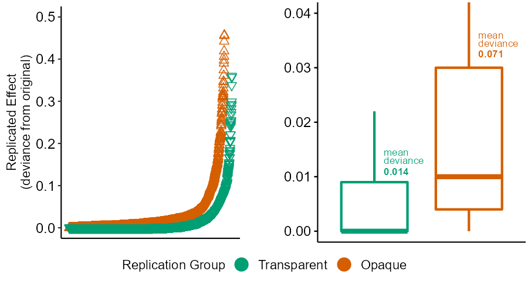

```r
knitr::include_graphics("results/Fig1.png")
```

## Table 2

### Setup

```r
# start with descriptive table

desc <- as.data.frame(matrix(nrow = 17, ncol = 11))

desc[1,] <- c("","","Means by Sample","","","Pear. Correlations w/ Raw Results","","","","","")

desc[2,] <- c("Variables","Measurement","Transparent","Opaque", "Pooled", "Verification", "Exact Verif.", "Deviance", "", "", "")

desc[,1] <- c("", "Variables","Raw Replication Results", "Verification", "Exact Verification", "Deviance", "Curated Replication Results", "Verification", "Exact Verification", "Deviance", "Independent Variables", "Stata", "Sociology Degree", "Stats-Skill", "Difficulty", "Team Size", "Transparent")

desc[,2] <- c("", "Measurement","", "same direction =1","identical at two decimals =1", "absolute difference with original","", "same direction =1","identical at two decimals =1", "absolute difference with original","", "other software =0","other degrees =0","4-question scale, stdzd,","1-question, stdzd.","1-3 persons","Transparent group =1")

# fill in transparent group results

desc[3:17,3] <- c("",
                  mean(cri_long$verif[cri_long$Exp1 == 1], na.rm = T),
                  mean(cri_long$exact[cri_long$Exp1 == 1], na.rm = T),
                  mean(cri_long$deviance_abs[cri_long$Exp1 == 1], na.rm = T),
                  "",
                  mean(cri_cur_long$verif[cri_cur_long$Exp1 == 1], na.rm = T),
                  mean(cri_cur_long$exact[cri_cur_long$Exp1 == 1], na.rm = T),
                  mean(cri_cur_long$deviance_abs[cri_cur_long$Exp1 == 1], na.rm = T),
                  "",
                  mean(cri_long$stata[cri_long$Exp1 == 1], na.rm = T),
                  mean(cri_long$degree_soc[cri_long$Exp1 == 1], na.rm = T),
                  mean(cri_long$stat_skill[cri_long$Exp1 == 1], na.rm = T),
                  mean(cri_long$difficult[cri_long$Exp1 == 1], na.rm = T),
                  mean(cri_long$numinteam[cri_long$Exp1 == 1], na.rm = T),
                  1)

# opaque

desc[3:17,4] <- c("",
                  mean(cri_long$verif[cri_long$Exp1 == 0], na.rm = T),
                  mean(cri_long$exact[cri_long$Exp1 == 0], na.rm = T),
                  mean(cri_long$deviance_abs[cri_long$Exp1 == 0], na.rm = T),
                  "",
                  mean(cri_cur_long$verif[cri_cur_long$Exp1 == 0], na.rm = T),
                  mean(cri_cur_long$exact[cri_cur_long$Exp1 == 0], na.rm = T),
                  mean(cri_cur_long$deviance_abs[cri_cur_long$Exp1 == 0], na.rm = T),
                  "",
                  mean(cri_long$stata[cri_long$Exp1 == 0], na.rm = T),
                  mean(cri_long$degree_soc[cri_long$Exp1 == 0], na.rm = T),
                  mean(cri_long$stat_skill[cri_long$Exp1 == 0], na.rm = T),
                  mean(cri_long$difficult[cri_long$Exp1 == 0], na.rm = T),
                  mean(cri_long$numinteam[cri_long$Exp1 == 0], na.rm = T),
                  0)

# pooled

desc[3:17,5] <- c("",
                  mean(cri_long$verif, na.rm = T),
                  mean(cri_long$exact, na.rm = T),
                  mean(cri_long$deviance_abs, na.rm = T),
                  "",
                  mean(cri_cur_long$verif, na.rm = T),
                  mean(cri_cur_long$exact, na.rm = T),
                  mean(cri_cur_long$deviance_abs, na.rm = T),
                  "",
                  mean(cri_long$stata, na.rm = T),
                  mean(cri_long$degree_soc, na.rm = T),
                  mean(cri_long$stat_skill, na.rm = T),
                  mean(cri_long$difficult, na.rm = T),
                  mean(cri_long$numinteam, na.rm = T),
                  mean(as.numeric(cri_long$u_expgroup1), na.rm = T))
```

### Make Table

```r
cri_long <- cri_long %>%
  ungroup()
cri_cur_long <- cri_cur_long %>%
  ungroup()


desc_c1 <- select(cri_long, verif, exact, deviance_abs, stata, degree_soc, stat_skill, difficult, numinteam, u_expgroup1)

desc_c1$u_expgroup1 <- as.numeric(desc_c1$u_expgroup1)

cor1 <- as.data.frame(cor(desc_c1, use = "pairwise"))

desc_c2 <- select(cri_cur_long, verif, exact, deviance_abs, stata, degree_soc, stat_skill, difficult, numinteam, u_expgroup1)

desc_c2$u_expgroup1 <- as.numeric(desc_c2$u_expgroup1)

cor2 <- as.data.frame(cor(desc_c2, use = "pairwise"))

# test for sig of corrs

test1 <- psych::corr.test(desc_c1)
test2 <- psych::corr.test(desc_c2)

test1df <- as.data.frame(round(test1[["p"]],3))[4:9,1:3]
test2df <- as.data.frame(round(test2[["p"]],3))[4:9,1:3]

# we drop 'other' as a degree because it does not have enough of any one degree type to be meaningful, and thus we just compare sociology and political science

desc_c1a <- subset(cri_long, degree != 3, select = c(verif, exact, deviance_abs, degree))
desc_c2a <- subset(cri_cur_long, degree != 3, select = c(verif, exact, deviance_abs, degree))

test1a <- psych::corr.test(desc_c1a)
test2a <- psych::corr.test(desc_c2a)

test1adfr <- as.data.frame(round(test1a[["r"]],3))[4,1:3]
test2adfr <- as.data.frame(round(test2a[["r"]],3))[4,1:3]

test1adfp <- as.data.frame(round(test1a[["p"]],3))[4,1:3]
test2adfp <- as.data.frame(round(test2a[["p"]],3))[4,1:3]

# update p value table with adjusted scores for degree

test1df[2,1:3] <- test1adfp
test2df[2,1:3] <- test2adfp

# add correlations to table

desc[4:6,6:8] <- cor1[1:3,1:3]

desc[12:17,6:8] <- cor1[4:9,1:3]

desc[8:10,9:11] <- cor2[1:3,1:3]

desc[12:17,9:11] <- cor2[4:9,1:3]

# add adjusted degree correlations
desc[13,6:8] <- test1adfr
desc[13,9:11] <- test2adfr

write.csv(desc, file = "results/Tbl2.csv")

cri_agg <- aggregate(cri_long, by = list(cri_long$u_teamid), FUN = mean)
cri_cur_agg <- aggregate(cri_cur_long, by = list(cri_cur_long$u_teamid), FUN = mean)

rm(test1, test2, test1a, test2a, test1df, test2df, test1adfp, test2adfp, test1adfr, test2adfr)
```

## Explaining Variance

Our observations take place only at the team level, therefore it is only necessary to run a regression on the team averages (‘level-2’) of the three outcome variables *verif*, *exact* and *deviance_abs*.

Aggregate data to team-level

```r
# curated
cri_team <- cri_cur_long %>%
  mutate(u_expgroup1 = as.numeric(u_expgroup1)) %>%
  group_by(u_teamid2) %>%
  summarize(verif_m = mean(verif, na.rm = T),
            verif_sd = sd(verif, na.rm = T),
            exact_m = mean(exact, na.rm = T),
            exact_sd = sd(exact, na.rm = T),
            dev_m = mean(deviance_abs, na.rm = T),
            dev_sd = sd(deviance_abs, na.rm = T),
            stata = mean(stata, na.rm = T),
            degree = mean(degree, na.rm = T),
            stat_skill = mean(stat_skill, na.rm = T),
            numinteam = mean(numinteam, na.rm = T),
            exp = mean(u_expgroup1, na.rm = T),
            difficult = mean(difficult, na.rm = T))
cri_team_orig <- cri_long %>%
  group_by(u_teamid2) %>%
  mutate(u_expgroup1 = as.numeric(u_expgroup1)) %>%
  summarize(verif_m = mean(verif, na.rm = T),
            verif_sd = sd(verif, na.rm = T),
            exact_m = mean(exact, na.rm = T),
            exact_sd = sd(exact, na.rm = T),
            dev_m = mean(deviance_abs, na.rm = T),
            dev_sd = sd(deviance_abs, na.rm = T),
            stata = mean(stata, na.rm = T),
            degree = mean(degree, na.rm = T),
            stat_skill = mean(stat_skill, na.rm = T),
            numinteam = mean(numinteam, na.rm = T),
            exp = mean(u_expgroup1, na.rm = T),
            difficult = mean(difficult, na.rm = T))
cri_team$degree <- factor(cri_team$degree, labels = c("Sociology", "Political Science", "Other"))
cri_team_orig$degree <- factor(cri_team_orig$degree, labels = c("Sociology", "Political Science", "Other"))

# trim outlier
cri_team$stat_skill <- ifelse(cri_team$stat_skill < -4, -4, cri_team$stat_skill)
cri_team_orig$stat_skill <- ifelse(cri_team_orig$stat_skill < -4, -4, cri_team_orig$stat_skill)
```

Variance decomposition

```r
# curated
mlm01_verif <- glmer(verif ~ (1 | u_teamid2), family = binomial, data = cri_cur_long)

mlm11_exact <- glmer(exact ~ (1 | u_teamid2), family = binomial, data = cri_cur_long)

mlm21_deviance <- lmer(deviance_abs ~ (1 | u_teamid2), data = cri_cur_long)

# original
mlm01_verif_orig <- glmer(verif ~ (1 | u_teamid2), family = binomial, data = cri_long)

mlm11_exact_orig <- glmer(exact ~ (1 | u_teamid2), family = binomial, data = cri_long)

mlm21_deviance_orig <- lmer(deviance_abs ~ (1 | u_teamid2), data = cri_long)

tab_model(mlm01_verif, mlm01_verif_orig, mlm11_exact, mlm11_exact_orig, mlm21_deviance, mlm21_deviance_orig,show.ci = F, file = "results/mlm.htm")
```

|  | verif |  | verif |  | exact |  | exact |  | deviance abs |  | deviance abs |  |
| --- | --- | --- | --- | --- | --- | --- | --- | --- | --- | --- | --- | --- |
| Predictors | Odds Ratios | p | Odds Ratios | p | Odds Ratios | p | Odds Ratios | p | Estimates | p | Estimates | p |
| (Intercept) | 4363.92 | **<0.001** | 381.11 | **<0.001** | 5.83 | **<0.001** | 3.47 | **<0.001** | 0.02 | **<0.001** | 0.05 | **0.004** |
| Random Effects |  |  |  |  |  |  |  |  |  |  |  |  |
| σ<sup>2</sup> | 3.29 |  | 3.29 |  | 3.29 |  | 3.29 |  | 0.00 |  | 0.00 |  |
| τ<sub>00</sub> | 30.89 <sub>u_teamid2</sub> |  | 14.05 <sub>u_teamid2</sub> |  | 8.07 <sub>u_teamid2</sub> |  | 9.79 <sub>u_teamid2</sub> |  | 0.00 <sub>u_teamid2</sub> |  | 0.02 <sub>u_teamid2</sub> |  |
| ICC | 0.90 |  | 0.81 |  | 0.71 |  | 0.75 |  | 0.50 |  | 0.92 |  |
| N | 87 <sub>u_teamid2</sub> |  | 87 <sub>u_teamid2</sub> |  | 87 <sub>u_teamid2</sub> |  | 87 <sub>u_teamid2</sub> |  | 87 <sub>u_teamid2</sub> |  | 87 <sub>u_teamid2</sub> |  |
| Observations | 3747 |  | 3742 |  | 3747 |  | 3742 |  | 3747 |  | 3742 |  |
| Marginal R<sup>2</sup> / Conditional R<sup>2</sup> | 0.000 / 0.904 |  | 0.000 / 0.810 |  | 0.000 / 0.710 |  | 0.000 / 0.748 |  | 0.000 / 0.503 |  | 0.000 / 0.922 |  |

```r
mlm <- as.data.frame(read_html("results/mlm.htm") %>% html_table(fill=TRUE))
```

### Variance Plots

```r
cri_cur_long <- cri_cur_long %>%
  mutate(degreeF = as.factor(degree),
         stataF = as.factor(stata),
         stat_skillF = as.factor(ifelse(stat_skill > 0, 1, 0)),
         dev_abs_log = log(deviance_abs+0.001),
         dev_abs_min = min(dev_abs_log, na.rm = T),
         dev_abs_log_c = dev_abs_log - dev_abs_min)

# alt summary stats by group
cri_sum_plot <- cri_cur_long %>%
  group_by(degree) %>%
  summarise(dev_degree = mean(deviance_abs, na.rm = T),
            dev_degree_sd = sd(deviance_abs, na.rm = T),
            dev_degree_n = n())
cri_sum_plot2 <- cri_cur_long %>%
  group_by(stataF, u_expgroup1) %>%
  summarise(dev_stataex = mean(deviance_abs, na.rm = T),
            dev_stataex_sd = sd(deviance_abs, na.rm = T),
            dev_stataex_n = n())
cri_sum_plot3 <- cri_cur_long %>%
  group_by(stat_skillF) %>%
  summarise(dev_stat = mean(deviance_abs, na.rm = T),
            dev_stat_sd = sd(deviance_abs, na.rm = T),
            dev_stat_n = n())
cri_sum_plot$degree <- as.factor(cri_sum_plot$degree)
cri_sum_plot2$stataF <- as.factor(cri_sum_plot2$stataF)
cri_sum_plot3$stat_skillF <- as.factor(cri_sum_plot3$stat_skillF)
```

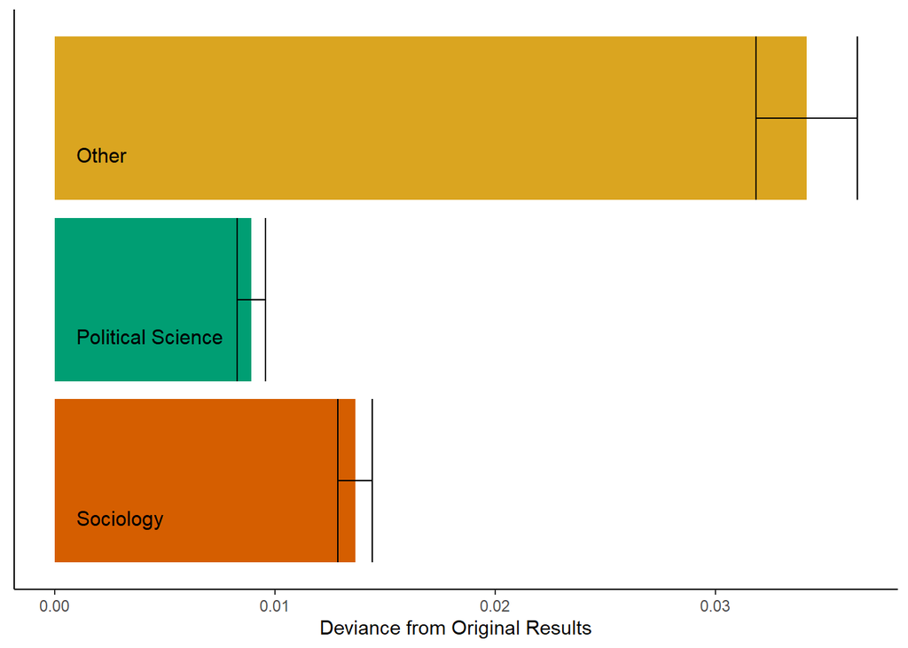

```r
ggplot(cri_sum_plot) +
  geom_bar(aes(y=dev_degree, x=degree, fill=degree), stat = 'identity') +
  geom_errorbar(aes(x=degree, ymin=dev_degree-(dev_degree_sd/sqrt(dev_degree_n)), ymax = dev_degree+(dev_degree_sd/sqrt(dev_degree_n)), fill=degree)) +
  coord_flip() +
  scale_fill_manual(values = c("#D55E00","#009E73","goldenrod")) +
  annotate(geom="text", x=2.8, y=0.001, label = paste0("Other"),
              color="black", size = 4, hjust = 0) +
  annotate(geom="text", x=1.8, y=0.001, label = paste0("Political Science"),
              color="black", size = 4, hjust = 0) +
  annotate(geom="text", x=0.8, y=0.001, label = paste0("Sociology"),
              color="black", size = 4, hjust = 0) +
  ylab(label = "Deviance from Original Results") +
  theme_classic() +
  theme(
    legend.position = "none",
    axis.text.y = element_blank(),
    axis.ticks.y = element_blank(),
    axis.title.y = element_blank()
  )
```

```r
cri_sum_plot2[,1] <- as.factor(c(1,3,2,4))

agg_png(filename = "results/Fig2.png", width = 800, height = 600, res = 144)
ggplot(cri_sum_plot2) +
  geom_bar(aes(y=dev_stataex, x=stataF, fill=stataF), stat = 'identity') +
  geom_errorbar(aes(x=stataF, ymin=dev_stataex-(dev_stataex_sd/sqrt(dev_stataex_n)), ymax = dev_stataex+(dev_stataex_sd/sqrt(dev_stataex_n)), width = 0.4)) +
  coord_flip() +
  scale_fill_manual(values = c("#D55E00","#009E73","goldenrod","mediumturquoise")) +
  geom_label(aes(x=3.8, y=0.0005, label = "Stata"), fill = "white",
              color="black", label.size = NA, hjust = 0, label.r = unit(0, "lines")) +
  geom_label(aes(x=2.8, y=0.0005, label = "Other"), fill = "white",
              color="black", label.size = NA, hjust = 0, label.r = unit(0, "lines")) +
  geom_label(aes(x=1.8, y=0.0005, label = "Stata"), fill = "white",
              color="black", label.size = NA, hjust = 0, label.r = unit(0, "lines")) +
  geom_label(aes(x=0.8, y=0.0005, label = "Other"), fill = "white",
              color="black", label.size = NA, hjust = 0, label.r = unit(0, "lines")) +
  annotate(geom = "text", label = "Transparent Group", y = -0.001, x = 3.5, angle = 90, vjust = 0) +
  annotate(geom = "text", label = "Opaque Group", y = -0.001, x = 1.5, angle = 90, vjust = 0) +
  geom_vline(xintercept = 2.5, color = "grey23") +
  ylab(label = "Deviance from Original Results") +
  theme_classic() +
  theme(
    legend.position = "none",
    axis.text.y = element_blank(),
    axis.ticks.y = element_blank(),
    axis.title.y = element_blank()
  )
dev.off()
```

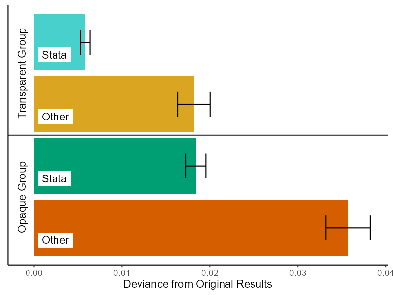

```r
knitr::include_graphics("results/Fig2.png")
```

[figure not shown]

```r
ggplot(cri_cur_long, aes(y=deviance_abs, x=degreeF, fill=degreeF)) +
  coord_flip(ylim = c(0,0.02)) +
  #coord_cartesian(ylim = c(0,0.15)) +
  geom_violinhalf() +
  theme_classic() +
  ylab(label = "Replicated Effect Deviance (logged)") +
  scale_fill_manual(values = c("#D55E00","#009E73","goldenrod")) +
  annotate(geom="text", x=2.9, y=0.001, label = paste0("Other"),
              color="goldenrod", size = 4, hjust = 0) +
  annotate(geom="text", x=1.9, y=0.001, label = paste0("Political Science"),
              color="#009E73", size = 4, hjust = 0) +
  annotate(geom="text", x=0.9, y=0.001, label = paste0("Sociology"),
              color="#D55E00", size = 4, hjust = 0) +
  theme(
    legend.position = "none",
    axis.text.y = element_blank(),
    axis.title.y = element_blank(),
    axis.ticks.y = element_blank()
  )
```

[figure not shown]

```r
ggplot(cri_cur_long, aes(y=deviance_abs, x=stataF, fill=stataF)) +
  coord_flip(ylim = c(0,0.02)) +
  #coord_cartesian(ylim = c(0,0.15)) +
  geom_violinhalf() +
  theme_classic() +
  ylab(label = "Replicated Effect Deviance (logged)") +
  scale_fill_manual(values = c("#D55E00","#009E73")) +
  annotate(geom="text", x=1.9, y=0.001, label = paste0("Stata"),
              color="#009E73", size = 4, hjust = 0) +
  annotate(geom="text", x=0.9, y=0.001, label = paste0("Other"),
              color="#D55E00", size = 4, hjust = 0) +
  theme(
    legend.position = "none",
    axis.text.y = element_blank(),
    axis.title.y = element_blank(),
    axis.ticks.y = element_blank()
  )
```

[figure not shown]

```r
ggplot(cri_cur_long, aes(y=deviance_abs, x=stat_skillF, fill=stat_skillF)) +
  coord_flip(ylim = c(0,0.02)) +
  #coord_cartesian(ylim = c(0,0.15)) +
  geom_violinhalf() +
  theme_classic() +
  ylab(label = "Replicated Effect Deviance (logged)") +
  scale_fill_manual(values = c("#D55E00","#009E73")) +
  annotate(geom="text", x=1.9, y=0.001, label = paste0("Less Stats Skills/Experience"),
              color="#009E73", size = 4, hjust = 0) +
  annotate(geom="text", x=0.9, y=0.001, label = paste0("More Stats Skills/Experience"),
              color="#D55E00", size = 4, hjust = 0) +
  theme(
    legend.position = "none",
    axis.text.y = element_blank(),
    axis.title.y = element_blank(),
    axis.ticks.y = element_blank()
  )
```

These regressions are interesting

### Regressions predicting within-team variance **curated**

```r
# variables, researcher aspects

# MEANS
m01_verif_mean <- lm(verif_m ~ exp + stata + stat_skill , data = cri_team)

m11_exact_mean <- lm(exact_m ~ exp + stata + stat_skill , data = cri_team)

m21_deviance_mean <- lm(dev_m ~ exp + stata + stat_skill , data = cri_team)

#SDs
m001_verif_sd <- lm(verif_sd ~ exp + stata + stat_skill , data = cri_team)

m011_exact_sd <- lm(exact_sd ~ exp + stata + stat_skill , data = cri_team)

m021_deviance_sd <- lm(dev_sd ~ exp + stata + stat_skill , data = cri_team)


# unimportant criteria

# MEANS
m02_verif_mean <- lm(verif_m ~ exp + stata + stat_skill  + degree + numinteam, data = cri_team)

m12_exact_mean <- lm(exact_m ~ exp + stata + stat_skill  + degree + numinteam, data = cri_team)

m22_deviance_mean <- lm(dev_m ~ exp + stata + stat_skill  + degree + numinteam, data = cri_team)

#SDs
m002_verif_sd <- lm(verif_sd ~ exp + stata + stat_skill  + difficult, data = cri_team)

m012_exact_sd <- lm(exact_sd ~ exp + stata + stat_skill  + difficult, data = cri_team)

m022_deviance_sd <- lm(dev_sd ~ exp + stata + stat_skill  + difficult, data = cri_team)


# difficulty

# MEANS
m03_verif_mean <- lm(verif_m ~ exp + stata + stat_skill + degree + numinteam + difficult + exp, data = cri_team)

m13_exact_mean <- lm(exact_m ~ exp + stata + stat_skill + degree + numinteam + difficult + exp, data = cri_team)

m23_deviance_mean <- lm(dev_m ~ exp + stata + stat_skill + degree + numinteam + difficult + exp, data = cri_team)

#SDs
m003_verif_sd <- lm(verif_sd ~ exp + stata + stat_skill  + difficult + exp, data = cri_team)

m013_exact_sd <- lm(exact_sd ~ exp + stata + stat_skill  + difficult + exp, data = cri_team)

m023_deviance_sd <- lm(dev_sd ~ exp + stata + stat_skill  + difficult + exp, data = cri_team)
```

### Regressions predicting within-team variance **original**

```r
# variables, researcher aspects

# MEANS
m01_verif_mean_orig <- lm(verif_m ~ exp + stata + stat_skill , data = cri_team_orig)

m11_exact_mean_orig <- lm(exact_m ~ exp + stata + stat_skill , data = cri_team_orig)

m21_deviance_mean_orig <- lm(dev_m ~ exp + stata + stat_skill , data = cri_team_orig)

#SDs
m001_verif_sd_orig <- lm(verif_sd ~ exp + stata + stat_skill , data = cri_team_orig)

m011_exact_sd_orig <- lm(exact_sd ~ exp + stata + stat_skill , data = cri_team_orig)

m021_deviance_sd_orig <- lm(dev_sd ~ exp + stata + stat_skill , data = cri_team_orig)


# Unimportant criteria

# MEANS
m02_verif_mean_orig <- lm(verif_m ~ exp + stata + stat_skill  + degree + numinteam, data = cri_team_orig)

m12_exact_mean_orig <- lm(exact_m ~ exp + stata + stat_skill  + degree + numinteam, data = cri_team_orig)

m22_deviance_mean_orig <- lm(dev_m ~ exp + stata + stat_skill  + degree + numinteam, data = cri_team_orig)

#SDs
m002_verif_sd_orig <- lm(verif_sd ~ exp + stata + stat_skill  + degree + numinteam, data = cri_team_orig)

m012_exact_sd_orig <- lm(exact_sd ~ exp + stata + stat_skill  + degree + numinteam, data = cri_team_orig)

m022_deviance_sd_orig <- lm(dev_sd ~ exp + stata + stat_skill  + degree + numinteam, data = cri_team_orig)


# Difficulty

# MEANS
m03_verif_mean_orig <- lm(verif_m ~ exp + stata + stat_skill + degree + numinteam + difficult + exp, data = cri_team_orig)

m13_exact_mean_orig <- lm(exact_m ~ exp + stata + stat_skill + degree + numinteam + difficult + exp, data = cri_team_orig)

m23_deviance_mean_orig <- lm(dev_m ~ exp + stata + stat_skill + degree + numinteam + difficult + exp, data = cri_team_orig)

#SDs
m003_verif_sd_orig <- lm(verif_sd ~ exp + stata + stat_skill  + difficult + exp, data = cri_team_orig)

m013_exact_sd_orig <- lm(exact_sd ~ exp + stata + stat_skill  + difficult + exp, data = cri_team_orig)

m023_deviance_sd_orig <- lm(dev_sd ~ exp + stata + stat_skill  + difficult + exp, data = cri_team_orig)
```

```r
cor <- select(cri_team, verif_m, exact_m, dev_m, stata, stat_skill, difficult)
cor1 <- cor(cor, use = "pairwise.complete.obs")

cor_orig <- select(cri_team_orig, verif_m, exact_m, dev_m, stata, stat_skill, difficult)
cor1_orig <- cor(cor_orig, use = "pairwise.complete.obs")
```

### Regression Tables Curated

```r
tab_model(m01_verif_mean, m02_verif_mean, m03_verif_mean, p.threshold = c(0.1, 0.05, 0.01), p.style = "star", show.ci = F)
```

verif m

verif m

verif m

Predictors

Estimates

Estimates

Estimates

(Intercept)

0.88 ***

0.92 ***

1.00 ***

exp

0.05 *

0.05 *

0.03

stata

0.06 **

0.05

0.02

stat_skill

0.00

0.00

-0.01

degree [Political  
Science]

0.03

0.03

degree [Other]

-0.07 *

-0.04

numinteam

-0.01

-0.04 **

difficult

-0.08 ***

Observations

87

87

87

R<sup>2</sup> / R<sup>2</sup> adjusted

0.082 / 0.049

0.161 / 0.098

0.305 / 0.244

- p<0.1 ** p<0.05 *** p<0.01

```r
tab_model(m11_exact_mean, m12_exact_mean, m13_exact_mean, p.threshold = c(0.1, 0.05, 0.01), p.style = "star", show.ci = F)
```

exact m

exact m

exact m

Predictors

Estimates

Estimates

Estimates

(Intercept)

0.46 ***

0.47 ***

0.60 ***

exp

0.26 ***

0.26 ***

0.24 ***

stata

0.16 **

0.13 *

0.09

stat_skill

-0.00

-0.00

-0.02

degree [Political  
Science]

0.05

0.04

degree [Other]

-0.13

-0.07

numinteam

0.01

-0.03

difficult

-0.14 ***

Observations

87

87

87

R<sup>2</sup> / R<sup>2</sup> adjusted

0.241 / 0.214

0.289 / 0.235

0.368 / 0.312

- p<0.1 ** p<0.05 *** p<0.01

```r
tab_model(m21_deviance_mean, m22_deviance_mean, m23_deviance_mean, p.threshold = c(0.1, 0.05, 0.01), p.style = "star", show.ci = F)
```

dev m

dev m

dev m

Predictors

Estimates

Estimates

Estimates

(Intercept)

0.04 ***

0.03 **

0.01

exp

-0.02 **

-0.02 **

-0.01 **

stata

-0.01 *

-0.01

-0.00

stat_skill

-0.00

-0.00

0.00

degree [Political  
Science]

-0.01

-0.01

degree [Other]

0.02 **

0.01

numinteam

-0.00

0.01

difficult

0.02 ***

Observations

87

87

87

R<sup>2</sup> / R<sup>2</sup> adjusted

0.106 / 0.073

0.214 / 0.155

0.390 / 0.336

- p<0.1 ** p<0.05 *** p<0.01

### Regression Tables Original

```r
tab_model(m01_verif_mean_orig, m02_verif_mean_orig, m03_verif_mean_orig, p.threshold = c(0.1, 0.05, 0.01), p.style = "star", show.ci = F)
```

verif m

verif m

verif m

Predictors

Estimates

Estimates

Estimates

(Intercept)

0.85 ***

0.87 ***

0.93 ***

exp

0.06 *

0.06 *

0.05

stata

0.07 **

0.07 *

0.05

stat_skill

0.00

0.00

-0.01

degree [Political  
Science]

0.05

0.04

degree [Other]

-0.04

-0.01

numinteam

-0.01

-0.03

difficult

-0.07 ***

Observations

87

87

87

R<sup>2</sup> / R<sup>2</sup> adjusted

0.089 / 0.056

0.132 / 0.066

0.212 / 0.143

- p<0.1 ** p<0.05 *** p<0.01

```r
tab_model(m11_exact_mean_orig, m12_exact_mean_orig, m13_exact_mean_orig, p.threshold = c(0.1, 0.05, 0.01), p.style = "star", show.ci = F)
```

exact m

exact m

exact m

Predictors

Estimates

Estimates

Estimates

(Intercept)

0.35 ***

0.33 **

0.45 ***

exp

0.27 ***

0.27 ***

0.25 ***

stata

0.20 ***

0.20 **

0.16 *

stat_skill

-0.01

-0.01

-0.03

degree [Political  
Science]

0.05

0.04

degree [Other]

-0.04

0.02

numinteam

0.01

-0.03

difficult

-0.14 ***

Observations

87

87

87

R<sup>2</sup> / R<sup>2</sup> adjusted

0.240 / 0.212

0.249 / 0.193

0.313 / 0.253

- p<0.1 ** p<0.05 *** p<0.01

```r
tab_model(m21_deviance_mean_orig, m22_deviance_mean_orig, m23_deviance_mean_orig, p.threshold = c(0.1, 0.05, 0.01), p.style = "star", show.ci = F)
```

dev m

dev m

dev m

Predictors

Estimates

Estimates

Estimates

(Intercept)

0.09 ***

0.08

0.09

exp

-0.06 *

-0.05 *

-0.06 *

stata

-0.03

-0.04

-0.04

stat_skill

-0.00

-0.00

-0.01

degree [Political  
Science]

0.00

-0.00

degree [Other]

-0.02

-0.02

numinteam

0.01

0.01

difficult

-0.01

Observations

87

87

87

R<sup>2</sup> / R<sup>2</sup> adjusted

0.050 / 0.016

0.058 / -0.013

0.060 / -0.023

- p<0.1 ** p<0.05 *** p<0.01

### Indirect Effects

There are clearly effects of these through perceived difficulty

```r
m1_diff <- lm(difficult ~ stata + stat_skill, data = cri_team)

m1_diff_orig <- lm(difficult ~ stata + stat_skill, data = cri_team_orig)

tab_model(m1_diff, m1_diff_orig, p.threshold = c(0.1, 0.05, 0.01), p.style = "star", show.ci = F)
```

difficult

difficult

Predictors

Estimates

Estimates

(Intercept)

0.29 **

0.29 **

stata

-0.46 ***

-0.46 ***

stat_skill

-0.13 ***

-0.13 ***

Observations

87

87

R<sup>2</sup> / R<sup>2</sup> adjusted

0.175 / 0.156

0.175 / 0.156

- p<0.1 ** p<0.05 *** p<0.01

### SEM

```r
m1 <- 'verif_m ~ exp + stata + stat_skill'
m2 <- 'verif_m ~ exp + stata + stat_skill + difficult'
m3 <- 'verif_m ~ exp + a2*stata + b2*stat_skill + m*difficult
       difficult ~ a1*stata + b1*stat_skill
       # total effects
         total_stata := a2 + (a1*m)
         total_stat_skill := b2 + (b1*m)
       # indirect effects
         indir_stata := a1*m
         indir_stat_skill := b1*m'

m1fit <- sem(m1, data = cri_team_orig)
m2fit <- sem(m2, data = cri_team_orig)
m3fit <- sem(m3, data = cri_team_orig)

m1out <- summary(m1fit, fit.measures = T)
```

```
## lavaan 0.6-7 ended normally after 16 iterations
##
##   Estimator                                         ML
##   Optimization method                           NLMINB
##   Number of free parameters                          4
##
##   Number of observations                            87
##
## Model Test User Model:
##
##   Test statistic                                 0.000
##   Degrees of freedom                                 0
##
## Model Test Baseline Model:
##
##   Test statistic                                 8.144
##   Degrees of freedom                                 3
##   P-value                                        0.043
##
## User Model versus Baseline Model:
##
##   Comparative Fit Index (CFI)                    1.000
##   Tucker-Lewis Index (TLI)                       1.000
##
## Loglikelihood and Information Criteria:
##
##   Loglikelihood user model (H0)                 44.112
##   Loglikelihood unrestricted model (H1)         44.112
##
##   Akaike (AIC)                                 -80.224
##   Bayesian (BIC)                               -70.360
##   Sample-size adjusted Bayesian (BIC)          -82.981
##
## Root Mean Square Error of Approximation:
##
##   RMSEA                                          0.000
##   90 Percent confidence interval - lower         0.000
##   90 Percent confidence interval - upper         0.000
##   P-value RMSEA <= 0.05                             NA
##
## Standardized Root Mean Square Residual:
##
##   SRMR                                           0.000
##
## Parameter Estimates:
##
##   Standard errors                             Standard
##   Information                                 Expected
##   Information saturated (h1) model          Structured
##
## Regressions:
##                    Estimate  Std.Err  z-value  P(>|z|)
##   verif_m ~
##     exp               0.062    0.031    1.957    0.050
##     stata             0.068    0.033    2.066    0.039
##     stat_skill        0.000    0.010    0.001    0.999
##
## Variances:
##                    Estimate  Std.Err  z-value  P(>|z|)
##    .verif_m           0.021    0.003    6.595    0.000
```

```r
m2out <- summary(m2fit, fit.measures = T)
```

```
## lavaan 0.6-7 ended normally after 24 iterations
##
##   Estimator                                         ML
##   Optimization method                           NLMINB
##   Number of free parameters                          5
##
##   Number of observations                            87
##
## Model Test User Model:
##
##   Test statistic                                 0.000
##   Degrees of freedom                                 0
##
## Model Test Baseline Model:
##
##   Test statistic                                16.317
##   Degrees of freedom                                 4
##   P-value                                        0.003
##
## User Model versus Baseline Model:
##
##   Comparative Fit Index (CFI)                    1.000
##   Tucker-Lewis Index (TLI)                       1.000
##
## Loglikelihood and Information Criteria:
##
##   Loglikelihood user model (H0)                 48.198
##   Loglikelihood unrestricted model (H1)         48.198
##
##   Akaike (AIC)                                 -86.397
##   Bayesian (BIC)                               -74.067
##   Sample-size adjusted Bayesian (BIC)          -89.844
##
## Root Mean Square Error of Approximation:
##
##   RMSEA                                          0.000
##   90 Percent confidence interval - lower         0.000
##   90 Percent confidence interval - upper         0.000
##   P-value RMSEA <= 0.05                             NA
##
## Standardized Root Mean Square Residual:
##
##   SRMR                                           0.000
##
## Parameter Estimates:
##
##   Standard errors                             Standard
##   Information                                 Expected
##   Information saturated (h1) model          Structured
##
## Regressions:
##                    Estimate  Std.Err  z-value  P(>|z|)
##   verif_m ~
##     exp               0.053    0.030    1.754    0.079
##     stata             0.039    0.033    1.202    0.230
##     stat_skill       -0.008    0.010   -0.849    0.396
##     difficult        -0.063    0.021   -2.927    0.003
##
## Variances:
##                    Estimate  Std.Err  z-value  P(>|z|)
##    .verif_m           0.019    0.003    6.595    0.000
```

```r
m3out <- summary(m3fit, fit.measures = T)
```

```
## lavaan 0.6-7 ended normally after 21 iterations
##
##   Estimator                                         ML
##   Optimization method                           NLMINB
##   Number of free parameters                          8
##
##   Number of observations                            87
##
## Model Test User Model:
##
##   Test statistic                                 0.842
##   Degrees of freedom                                 1
##   P-value (Chi-square)                           0.359
##
## Model Test Baseline Model:
##
##   Test statistic                                33.944
##   Degrees of freedom                                 7
##   P-value                                        0.000
##
## User Model versus Baseline Model:
##
##   Comparative Fit Index (CFI)                    1.000
##   Tucker-Lewis Index (TLI)                       1.041
##
## Loglikelihood and Information Criteria:
##
##   Loglikelihood user model (H0)                -44.141
##   Loglikelihood unrestricted model (H1)        -43.720
##
##   Akaike (AIC)                                 104.282
##   Bayesian (BIC)                               124.010
##   Sample-size adjusted Bayesian (BIC)           98.767
##
## Root Mean Square Error of Approximation:
##
##   RMSEA                                          0.000
##   90 Percent confidence interval - lower         0.000
##   90 Percent confidence interval - upper         0.274
##   P-value RMSEA <= 0.05                          0.409
```

[output cut: 18 more lines]

```
##   difficult ~
##     stata     (a1)   -0.461    0.158   -2.925    0.003
##     stat_skll (b1)   -0.129    0.046   -2.782    0.005
##
## Variances:
##                    Estimate  Std.Err  z-value  P(>|z|)
##    .verif_m           0.019    0.003    6.595    0.000
##    .difficult         0.489    0.074    6.595    0.000
##
## Defined Parameters:
##                    Estimate  Std.Err  z-value  P(>|z|)
##     total_stata       0.068    0.033    2.079    0.038
##     total_stt_skll   -0.000    0.010   -0.010    0.992
##     indir_stata       0.029    0.014    2.074    0.038
##     indir_stt_skll    0.008    0.004    2.021    0.043
```

```r
# not really ideal for showing all features of the model
# lavaanPlot(model = m3fit, coefs = T, stand = T, sig = 1.00)

# m1out[["FIT"]][["aic"]]
```

What led to mistakes - lack of transparency, working in the same software as the original - some kind of procedural similarity that is unique to softwares.

### Predict routine v. non-routine